# Problem set 3: Under pressure

S470/670

1/17/2018

## Preliminaries

Load packages:

```r
library(NHANES)
library(tidyverse)  # includes ggplot2, dplyr
library(broom)
```

Have a quick peek at the data:

```r
summary(NHANES$BPSysAve)
```

```
##    Min. 1st Qu.  Median    Mean 3rd Qu.    Max.    NA's
##    76.0   106.0   116.0   118.2   127.0   226.0    1449
```

```r
aggregate(BPSysAve ~ Gender, mean, data = NHANES)
```

```
##   Gender BPSysAve
## 1 female 116.3064
## 2   male 120.0240
```

```r
aggregate(BPSysAve ~ Gender, sd, data = NHANES)
```

```
##   Gender BPSysAve
## 1 female 17.81539
## 2   male 16.44721
```

Typical systolic blood pressure (hereafter “SBP”) is 106 to 127 mmHg. On average, males have 4 units higher SBP. Perhaps surprisingly, females have a slightly larger standard deviation (17.8 to 16.4.)

## Age and systolic blood pressure

I’m fond of relatively smooth fits. Since there’s no reason to expect linearity (and since I slightly prefer loess to splines), I’ll go with degree 1 loess fits unless there seems to be a good reason to do otherwise. For simplicity, I won’t transform anything here.

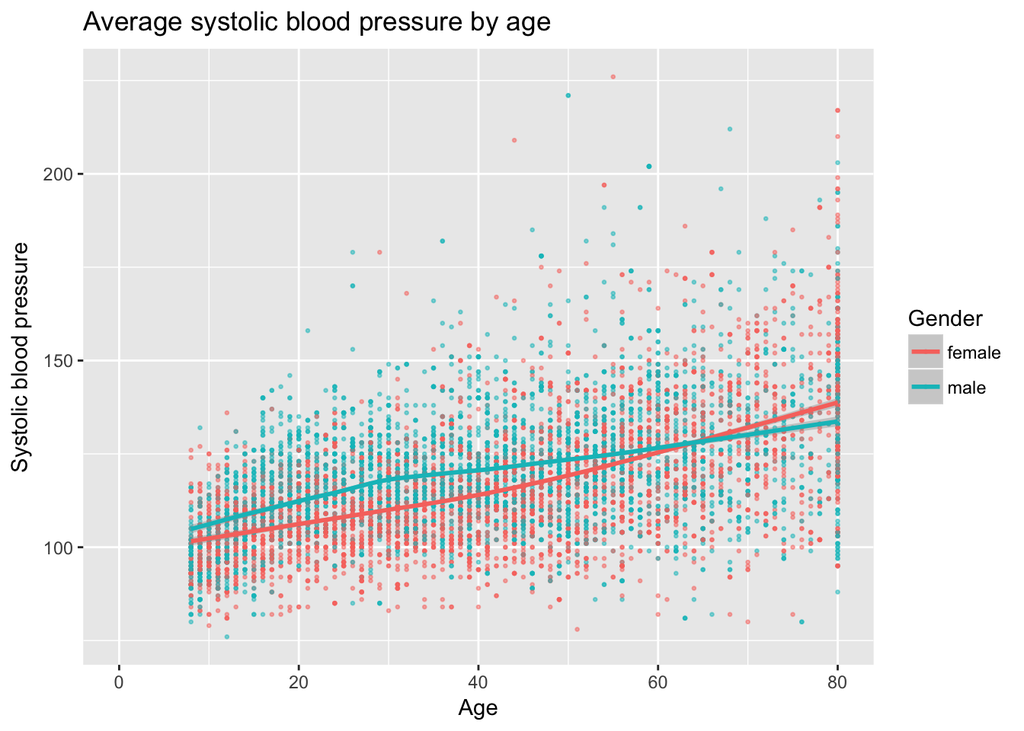

```r
ggplot(NHANES, aes(x = Age, y = BPSysAve, group = Gender, color = Gender)) +
    geom_point(size = 0.5, alpha = 0.5) + geom_smooth(method = "loess", method.args = list(degree = 1)) +
    ylab("Systolic blood pressure") + ggtitle("Average systolic blood pressure by age")
```

For both men and women, average SBP goes up with age. However, the trend lines cross: below 65, men tend to have higher SBP, while above 65, women tend to have higher SBP.

Fit separate loess models for males and females:

```r
AgeF.lo = loess(BPSysAve ~ Age, degree = 1, data = subset(NHANES, Gender ==
    "female"))
AgeF.df = augment(AgeF.lo)
sd(AgeF.df$.resid)
```

```
## [1] 14.29245
```

```r
var(AgeF.df$.fitted)/(var(AgeF.df$.fitted) + var(AgeF.df$.resid))
```

```
## [1] 0.3539158
```

```r
AgeM.lo = loess(BPSysAve ~ Age, degree = 1, data = subset(NHANES, Gender ==
    "male"))
AgeM.df = augment(AgeM.lo)
sd(AgeM.df$.resid)
```

```
## [1] 14.61636
```

```r
var(AgeM.df$.fitted)/(var(AgeM.df$.fitted) + var(AgeM.df$.resid))
```

```
## [1] 0.2032134
```

The SD of the residuals is between 14–15 for both models. The model for females captures 35% of the variance in SBP, compared to 20% for the model for males. That’s just because there’s more variation by age for women (which also explains why the SD was higher for females.)

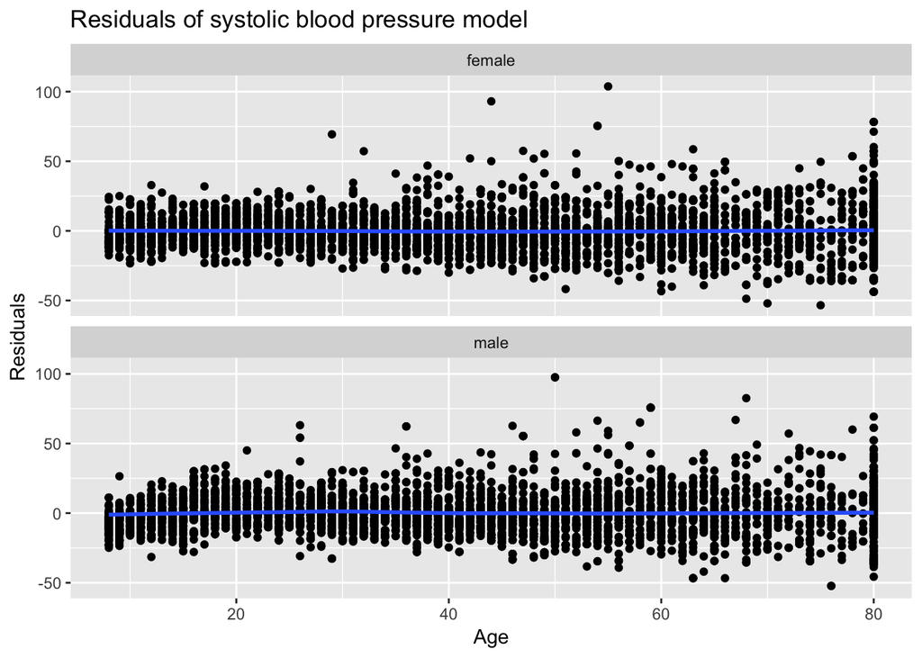

```r
Age.df = bind_rows(list(female = AgeF.df, male = AgeM.df), .id = "gender")
ggplot(Age.df, aes(x = Age, y = .resid)) + geom_point() + facet_wrap(~gender,
    ncol = 1) + geom_smooth(method = "loess", method.args = list(degree = 1)) +
    ylab("Residuals") + ggtitle("Residuals of systolic blood pressure model")
```

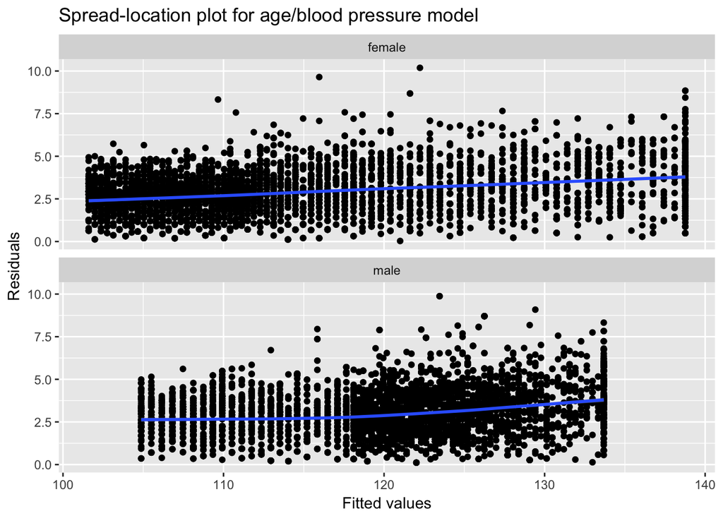

```r
ggplot(Age.df, aes(x = .fitted, y = sqrt(abs(.resid)))) + geom_point() + facet_wrap(~gender,
    ncol = 1) + geom_smooth(method = "loess", method.args = list(degree = 1)) +
    xlab("Fitted values") + ylab("Residuals") + ggtitle("Spread-location plot for age/blood pressure model")
```

The model appears to have done a good job of capturing the trend. The residuals are heteroskedastic, which isn’t a problem now but would be an annoyance if the researcher ever does formal inference.

## Weight and systolic blood pressure

Without transformation, the smoother gets a little finicky for high weights (where there is little data), so I’ll do a (base 2) log transformation of weight. We start out fitting loess curves for males and females separately. Some trial and error suggests degree 2 loess looks a little nicer than degree 1, though this is subjective.

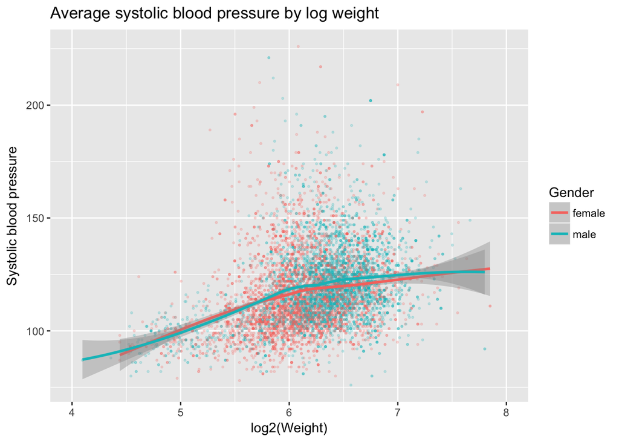

```r
ggplot(NHANES, aes(x = log2(Weight), y = BPSysAve, group = Gender, color = Gender)) +
    geom_point(size = 0.5, alpha = 0.2) + geom_smooth(method = "loess") + xlim(4,
    8) + ylab("Systolic blood pressure") + ggtitle("Average systolic blood pressure by log weight")
```

This time there’s very little difference between the trend lines for males and females: both rise with log weight with similar positions and shapes. (This suggests, but does not prove, that the differences between males and females in the other models may be largely explained by weight.) Males look to be a little higher in SBP for the upper half of the weight distribution, with the difference biggest around 6.5–6.6 (90-something kilos.) This would be important for prediction (since the observations are still dense there), but even at its biggest the difference looks relatively unimportant compared to the differences between low and high weights. So to simplify further, I’ll now fit one loess model for males and females together.

```r
logWeight.lo = loess(BPSysAve ~ log2(Weight), data = NHANES)
logWeight.df = augment(logWeight.lo)
sd(logWeight.df$.resid)
```

```
## [1] 16.2915
```

```r
var(logWeight.df$.fitted)/(var(logWeight.df$.fitted) + var(logWeight.df$.resid))
```

```
## [1] 0.09903847
```

The SD of the residuals is about 16 units. Only about 10% of variance in SBP is captured by the model. So age and gender together are more informative than weight alone (and probably more more informative than weight and gender together), though that doesn’t mean that weight has no effect.

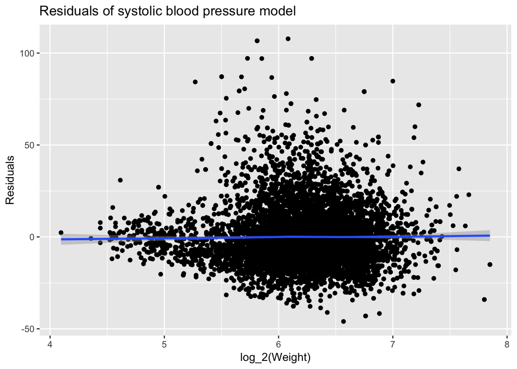

```r
ggplot(logWeight.df, aes(x = log2.Weight., y = .resid)) + geom_point() + geom_smooth(method = "loess",
    method.args = list(degree = 1)) + xlab("log_2(Weight)") + ylab("Residuals") +
    ggtitle("Residuals of systolic blood pressure model")
```

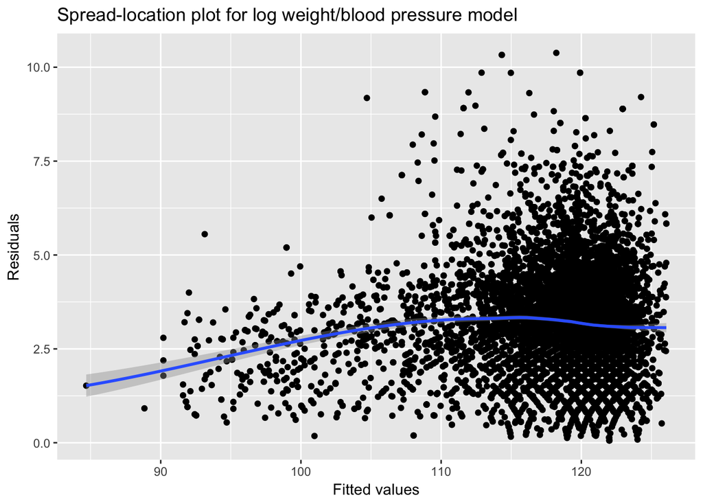

```r
ggplot(logWeight.df, aes(x = .fitted, y = sqrt(abs(.resid)))) + geom_point() +
    geom_smooth(method = "loess", method.args = list(degree = 1)) + xlab("Fitted values") +
    ylab("Residuals") + ggtitle("Spread-location plot for log weight/blood pressure model")
```

The model looks to have captured the trend in weight. The residuals don’t look homoskedastic, though the problem is mostly with low weights/fitted values (perhaps removing children would alleviate this.)

## Height and systolic blood pressure

For interpretability, I didn’t transform anything. After trial and error, I though a degree 2 loess looked a little better than a degree 1.

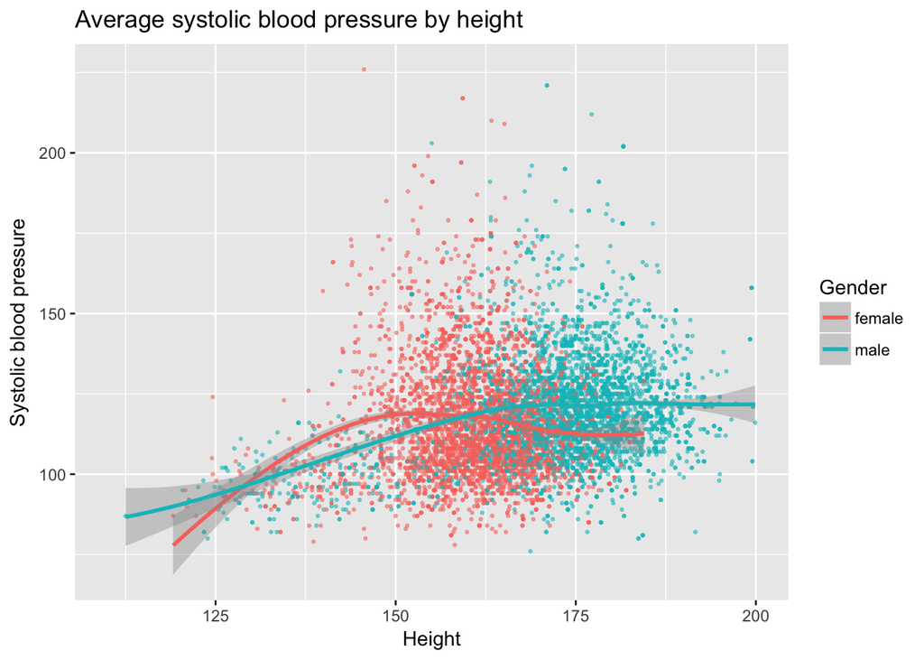

```r
ggplot(NHANES, aes(x = Height, y = BPSysAve, group = Gender, color = Gender)) +
    geom_point(size = 0.5, alpha = 0.5) + geom_smooth(method = "loess") + xlim(110,
    200) + ylab("Systolic blood pressure") + ggtitle("Average systolic blood pressure by height")
```

The two curves have dramatically different shapes. The curve for males rises, then levels out for heights around the 170s. The curves for females rises quickly to a peak around 152 cm, then *declines* as height continues to increase. I conjecture this is due to age as a lurking variable: the shortest females are predominantly children, while women in their 20s and 30s are on average taller than senior women.

```r
HeightF.lo = loess(BPSysAve ~ Height, data = subset(NHANES, Gender == "female"))
HeightF.df = augment(HeightF.lo)
sd(HeightF.df$.resid)
```

```
## [1] 17.42821
```

```r
var(HeightF.df$.fitted)/(var(HeightF.df$.fitted) + var(HeightF.df$.resid))
```

```
## [1] 0.03155731
```

```r
HeightM.lo = loess(BPSysAve ~ Height, data = subset(NHANES, Gender == "male"))
HeightM.df = augment(HeightM.lo)
sd(HeightM.df$.resid)
```

```
## [1] 15.58512
```

```r
var(HeightM.df$.fitted)/(var(HeightM.df$.fitted) + var(HeightM.df$.resid))
```

```
## [1] 0.0745818
```

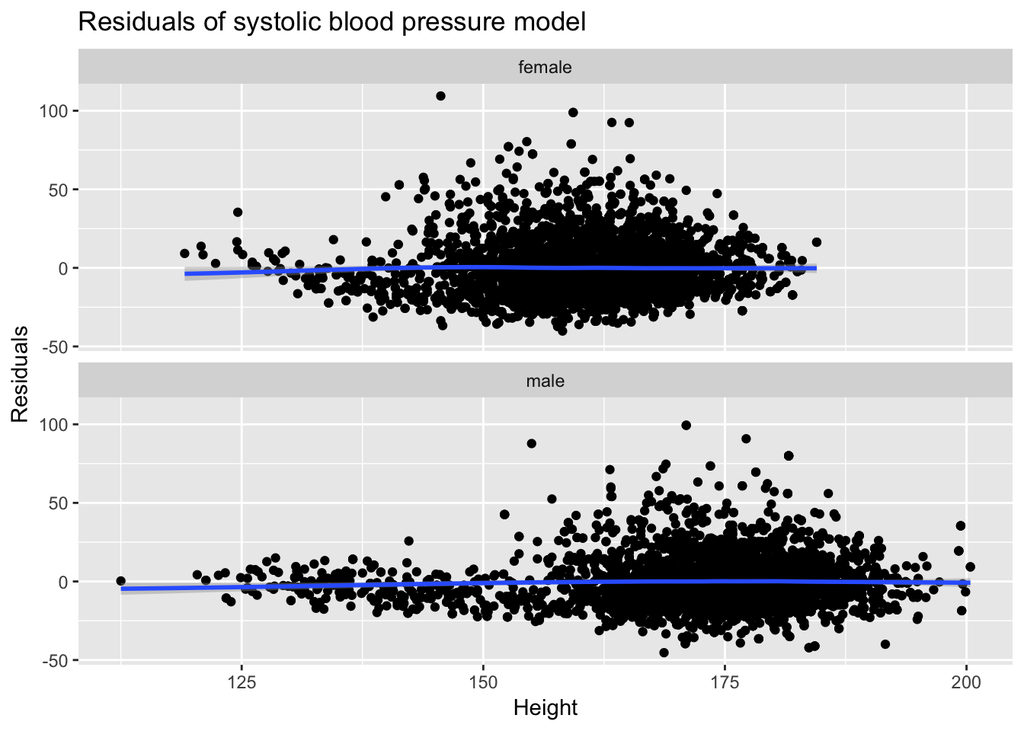

```r
Height.df = bind_rows(list(female = HeightF.df, male = HeightM.df), .id = "gender")
ggplot(Height.df, aes(x = Height, y = .resid)) + geom_point() + facet_wrap(~gender,
    ncol = 1) + geom_smooth(method = "loess", method.args = list(degree = 1)) +
    ylab("Residuals") + ggtitle("Residuals of systolic blood pressure model")
```

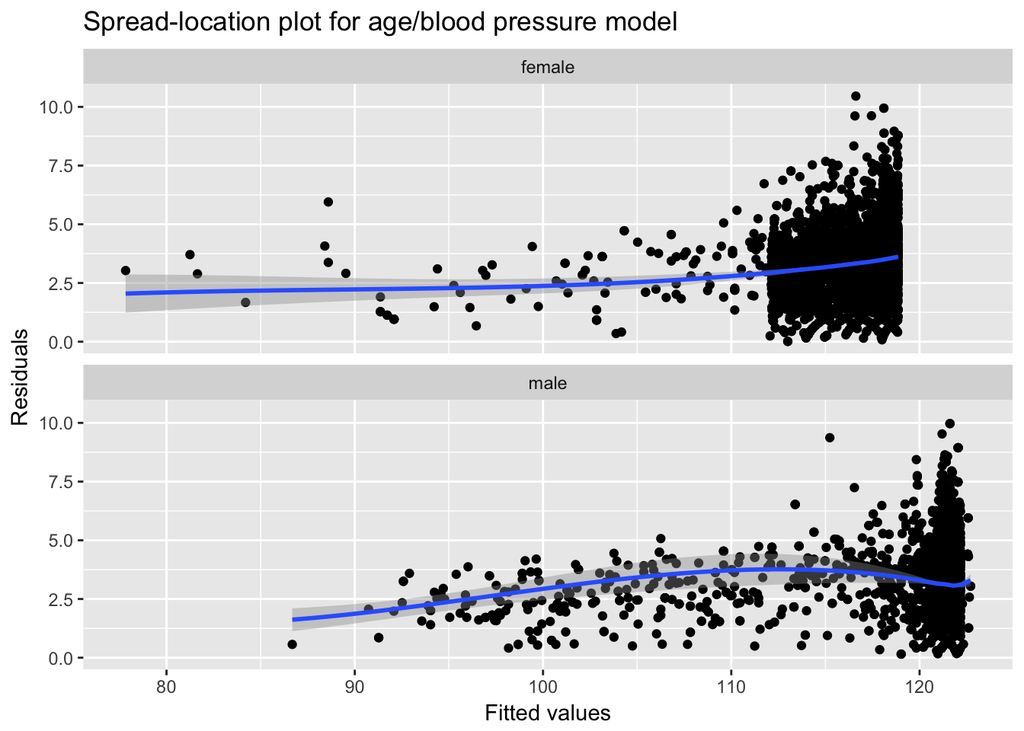

```r
ggplot(Height.df, aes(x = .fitted, y = sqrt(abs(.resid)))) + geom_point() +
    facet_wrap(~gender, ncol = 1) + geom_smooth(method = "loess", method.args = list(degree = 1)) +
    xlab("Fitted values") + ylab("Residuals") + ggtitle("Spread-location plot for age/blood pressure model")
```

The model is heteroskedastic. It’s a bit questionable for low heights, which again mostly means children. This model probably isn’t much use unless we refit it with the data set restricted to adults.

## Conclusion

The trend in systolic blood pressure by age looks quite different for males and females. In contrast, the trend in systolic blood pressure by weight looks relatively similar for males and females. The trend by height differs by gender, but this is confounded and height doesn’t tell you much anyway. A good starting point for a more complex model would include both age and weight as predictors.